# Poročilo pri predmetu Analiza podatkov v programom R

Žan Jarc

# Izbira teme

V projektni nalogi bom analiziral trg rabljenih vozil v Sloveniji. Najprej bom primerjal kateri modeli in katere znamke avtomobilov so najpopularnejši. V nadaljevanju bom analiziral, kakšni avtomobili so se prodajali glede na tip motorja. Analiziral bom tudi kako se cena avtomobila spreminja s starostjo avtomobila, pogojno na znamko avtomobila. Avtomobile bom na podlagi njihove kilometrine, starosti in cene uvrstil v skupine in tako vsakemu avtombilu določil, ali gre za nov avto, rabljen avtomobil ali “kripo”.

# Obdelava, uvoz in čiščenje podatkov

Uvozi sem podatke o prodajanih avtomobilih v Sloveniji iz spletne strani avto.net. Na spletni strani pod rubriko “Top 100” se dnevno osvežuje seznam zadnjih 100 oglasov. Podatki so v razpredelnici v obliki *tidy data*.

- ‘Znamka’ - spremenljivka: ime znamke avtomobila (character)
- ‘Model’ - spremenljvika: ime modela avtomobila (character)
- ‘Letnik’ - meritev: leto prve registracije vozila (integer)
- ‘Kilometrina’ - meritev: število prevoženih kilometrov vozila (integer)
- ‘Motor’ - spremenljvika: vrsta motorja vozila (character)
- ‘Velikost_motorja’ - meritev: volumen motorja (integer)
- ‘Menjalnik’ - spremenljvika: vrsta menjalnika vozila (character)
- ‘Cena’ - meritev: cena vozila (integer)
- ‘Cas_pridobitve_podatkov’ - meritev: datum kdaj so bili pridobljeni podatki (character)

Vir podatkov: [avto.net](https://www.avto.net/Ads/results_100.asp?oglasrubrika=1&prodajalec=2)

# Analiza in vizualizacija podatkov

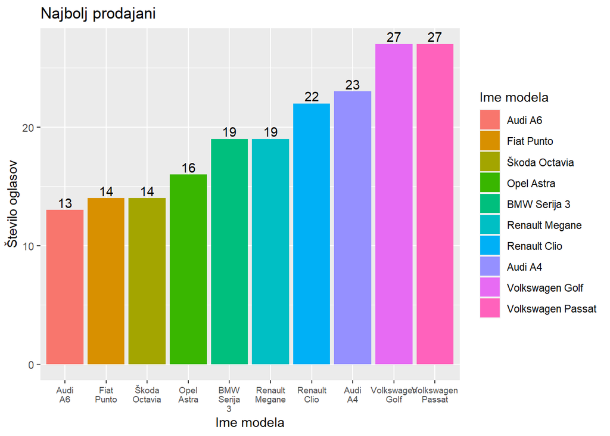

Pri pregledu števila avtomobilov glede na vrsto motorja oz. vrsto goriva nas preseneti prevladujoče število vozil z diesel motorjem (skoraj 70% prodajanih avtomobilov se poganja na dieselsko gorivo). Eden izmed razlogov bi lahko bil, da se rabljena vozila ponavadi prodajajo, ko se lastnik odloči za nakup novejšega oz. boljšega avtomobila; tako med oglasi večinoma pristanejo starejši modeli, pri starejših modelih pa prevladujejo diesel motorji.

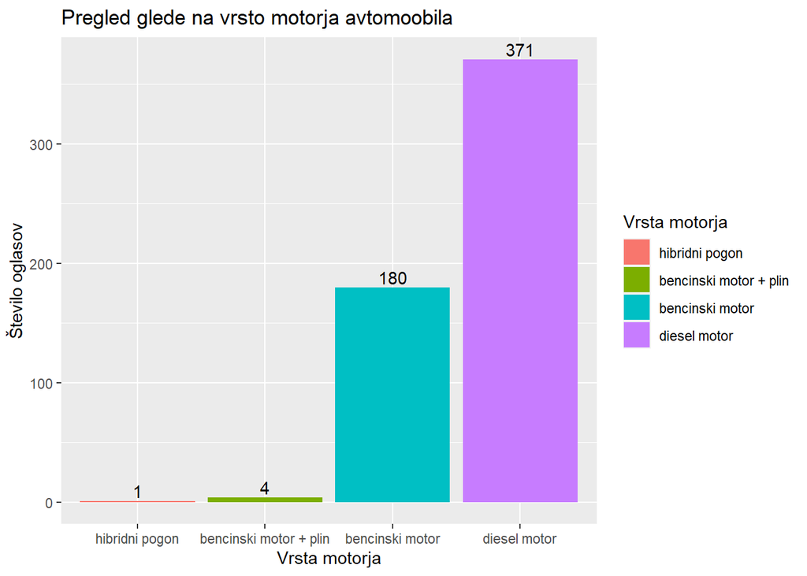

[figure not shown]

Rad bi izmeril, kako močno lastnosti vozila (število prevoženih kilometrov, letnik prve registracije, ipd.) vplivajo na ceno vozilo. Da se izognemo osamelcem, ki bi pokvarili analizo, sem vključil le tista vozila, ki so bila registrirana po letu 1990 in njihova cena ne presega 50.000 EUR.

Tabela znamk vozil z vsaj 10 oglasi

| Znamke | Število oglasov |
| --- | --- |
| Volkswagen | 78 |
| Renault | 61 |
| Audi | 55 |
| BMW | 50 |
| Opel | 38 |
| Peugeot | 38 |
| Citroen | 32 |
| Mercedes-Benz | 27 |
| Fiat | 25 |
| Ford | 24 |
| Škoda | 20 |
| Hyundai | 15 |
| Kia | 15 |
| Nissan | 12 |

Pri pregledu linearne odvisnosti cene vozila od letnice prve registracije sem dodatno vozila še razdelil glede na znamko vozila (v analizo so le tiste znamke vozil, ki imajo več kot 10 oglasov), saj ima na ceno vozila pomemben vpliv tudi znamka vozila, želel pa sem ugotoviti kako letinca prve registracije vpliva na ceno za vsako znamko.

Za znamke Audi, Hyundai, Nissan, Opel in Peugeot bi lahko s samo letico prve registracije vozila zelo dobro ocenili ceno vozila, saj je linearna regresija dokaj natančna (glede na vrednost R<sup>2</sup>). Vseeno je malce presenetljivo, saj je v analizo vključenih le 12 vozil znamke Nissan in 15 vozil znamke Hyundai, medtem ko je vozil znamke Audi 55.

Presenetljiva je tudi nenatančnost linearne regresije za vozila znamke Volkswagen, kjer je R<sup>2</sup> dokaj nizek, pa čeprav je v analizo vključenih 78 vozil znamke VW.

V analizi se tudi opazi vpliv znamk na ceno avtomobila. Če je regresijski koeficient za znamke Opel, Peugeot in Renault pod 1000, je koeficient pri bolj priznanih znamkah, kot so Audi, BMW in Mercedes-Benz vsaj 1200.

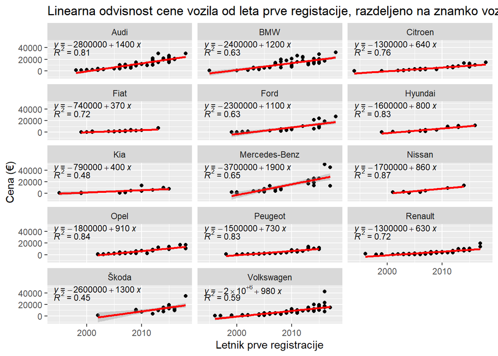

Za pregled razvrščanja vozil sem naredil aplikacijo Shiny. Razvrščanje deluje glede na letnik prve registracije vozila, število prevoženih kilometrov in velikostji motorja.

V tem projektu sem preveril, kako nekatere karakteristike trga rabljenih avtomobilov Sloveniji. Večina najosnovenjših ugotovitev, npr. najbolj prodajani modeli in znamke me niso presenečale, Volkswagen in nemška podjetja še vedno trdno držijo primat na trgu vozil v Sloveiji.

V analizo je bilo vključenih skoraj 600 oglasov za vozila. Za popolnejšo analizo, bi potreboval večjo količino podatkov, ki bi jih pridobival vsak dan. S tem bi lahko tudi ocenil/potrdil dvig cen rabljenih avtomobilov v letih 2020 in 2021, prav tako pa bi lahko opazoval ceno enakih modelov vozil skozi čas.